# San Francisco Wild Parrot Data

Hello! This Jupyter Notebook is used to access and view data about the San Francisco Wild Parrots! The San Francisco Wild Parrots are known by their distincitve green bodies, red colored heads, and loud calls. First making appearances in the 1990s, these Cherry-headed conures (Psittacara erythrogenys) are not native to San Francisco and are believed to have originated from Ecuador and Peru. In this Notebook, we'll take a closer look at the sightings of these special parrots in San Francisco. We will access this data through the BirdData module that's been provided.

## Getting Started

First, let's import the Data class from the BirdData module and assign it to the `data` variable. The Data class opens and cleans the data related to parrot sightings around San Francisco.

```python
from BirdData import Data
data = Data()
```

Next, we'll view all of the recorded sightings in a DataFrame. To do this, we'll access the `sightings` attribute of our Data class.

```python
data.sightings
```

|  | day | month | year | decimalLatitude | decimalLongitude | geometry | name |
| --- | --- | --- | --- | --- | --- | --- | --- |
| 0 | 31 | 1 | 2007 | 37.802326 | -122.405975 | POINT (-122.40597 37.80233) | Telegraph Hill |
| 1 | 12 | 10 | 2013 | 37.804996 | -122.418564 | POINT (-122.41856 37.80500) | Fishermans Wharf |
| 3 | 8 | 8 | 2009 | 37.803250 | -122.406020 | POINT (-122.40602 37.80325) | Telegraph Hill |
| 4 | 7 | 4 | 2009 | 37.801037 | -122.410150 | POINT (-122.41015 37.80104) | North Beach |
| 5 | 7 | 10 | 2012 | 37.769646 | -122.457730 | POINT (-122.45773 37.76965) | Golden Gate Park |
| ... | ... | ... | ... | ... | ... | ... | ... |
| 16577 | 1 | 1 | 2014 | 37.795930 | -122.396470 | POINT (-122.39647 37.79593) | Financial District |
| 16578 | 1 | 1 | 2014 | 37.802834 | -122.401420 | POINT (-122.40142 37.80283) | Northern Waterfront |
| 16579 | 2 | 1 | 2014 | 37.795930 | -122.396470 | POINT (-122.39647 37.79593) | Financial District |
| 16581 | 1 | 1 | 2014 | 37.804276 | -122.421104 | POINT (-122.42110 37.80428) | Russian Hill |
| 16582 | 1 | 1 | 2014 | 37.801044 | -122.419750 | POINT (-122.41975 37.80104) | Russian Hill |

11133 rows × 7 columns

## Searching for the Parrots

The Data class of the BirdData module has several methods to find where the parrots are sighted the most.

### Most Frequent Locations

The `most_freq_loc()` method returns a list of tuples containing the neighborhood and coordinates that the parrots are sighted the most throughout San Francisco. It also displays a map showing those coordinates. Let's iterate through that list and print the map.

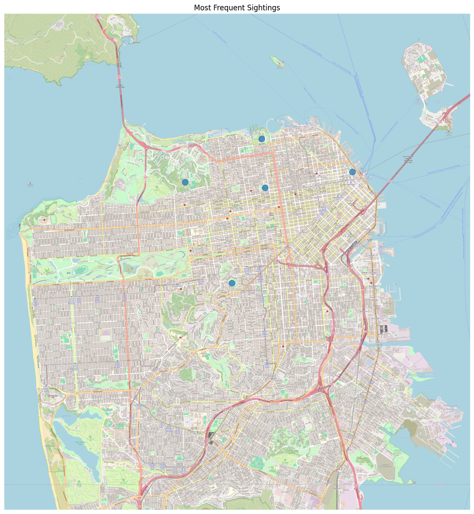

```
Coordinates: (Latitude: 37.80518, Longitude: -122.42855)
Neighborhood: Aquatic Park / Ft. Mason

Coordinates: (Latitude: 37.791473, Longitude: -122.42735)
Neighborhood: Pacific Heights

Coordinates: (Latitude: 37.764744, Longitude: -122.439026)
Neighborhood: Corona Heights

Coordinates: (Latitude: 37.79593, Longitude: -122.39647)
Neighborhood: Financial District

Coordinates: (Latitude: 37.793015, Longitude: -122.45557)
Neighborhood: Presidio National Park
```

```python
for location in data.most_freq_loc():
    print(f'Coordinates: (Latitude: {location[1]}, Longitude: {location[2]})')
    print(f'Neighborhood: {location[0]}')
    print()
```

So, according to this list, which location had the most sightings of the parrots? If you want know where a specific location is, just copy and paste those coordinates in Google Maps and maybe you'll see the parrots there!

### Searching By Season

Another method we can use is the `by_season()` method. The method takes a parameter, which is a string that represents a season. The method returns a tuple containing the locations the parrots are most frequently seen during a given season, the amount of sightings during a a given season, and the percentage of total sightings that take are reported during a given season. For the sake of this dataset, we have divided the seasons as follows: `winter` will return the locations the parrots frequent the most during the months of December, January, February. `spring` will return the most frequent locations during March, April and May. `summer` corresponds to the months of June, July, and August. `fall` corresponds to the months of September, October, and November. For this example, we'll check the Spring months. Change the `season` variable to see the corresponding season!

```python
season = 'spring'
for location in data.by_season(season)[0]:
    print(f'Coordinates: (Latitude: {location[1]}, Longitude: {location[2]})')
    print(f'Neighborhood: {location[0]}')
    print()
print(f'During the {season} seasons, there were {data.by_season(season)[1]} sightings of the parrots, which is about {data.by_season(season)[2]:.2f}% of all sightings.')
```

```
Coordinates: (Latitude: 37.80518, Longitude: -122.42855)
Neighborhood: Aquatic Park / Ft. Mason

Coordinates: (Latitude: 37.791473, Longitude: -122.42735)
Neighborhood: Pacific Heights

Coordinates: (Latitude: 37.793015, Longitude: -122.45557)
Neighborhood: Presidio National Park

Coordinates: (Latitude: 37.764744, Longitude: -122.439026)
Neighborhood: Corona Heights

Coordinates: (Latitude: 37.80325, Longitude: -122.40602)
Neighborhood: Telegraph Hill

During the spring seasons, there were 3046 sightings of the parrots, which is about 27.36% of all sightings.
```

While there are some common locations across all the seasons, there is definitely some variation throughout the year.

### Searching By Neighborhood

#### Printing the List of Neighborhoods

The Data class of the BirdData module also has several methods for finding data related to specific neighborhoods and how often the parrots are sighted there. First, let's find out what neighborhoods we can search through. The `print_neighborhoods()` method returns a list of all the neighborhoods that the parrots have been sighted in. We'll iterate through that list.

```python
for n in data.print_neighborhoods():
    print(n)
```

```
Alamo Square
Anza Vista
Apparel City
Aquatic Park / Ft. Mason
Ashbury Heights
Balboa Terrace
Bayview
Bernal Heights
Bret Harte
Buena Vista
Candlestick Point SRA
Cathedral Hill
Cayuga
Central Waterfront
Chinatown
Civic Center
Clarendon Heights
Cole Valley
Corona Heights
Cow Hollow
Crocker Amazon
Diamond Heights
Dogpatch
Dolores Heights
Downtown / Union Square
Duboce Triangle
Eureka Valley
Excelsior
Fairmount
Financial District
Fishermans Wharf
Forest Hill
Forest Knolls
Glen Park
Golden Gate Heights
Golden Gate Park
Haight Ashbury
Hayes Valley
Holly Park
Inner Richmond
```

[output cut: 44 more lines]

```
Silver Terrace
South Beach
South of Market
St. Marys Park
Sunnydale
Sunnyside
Sutro Heights
Telegraph Hill
Tenderloin
Union Street
University Mound
Upper Market
Visitacion Valley
West Portal
Western Addition
```

#### Frequent Locations Within Neighborhoods

Now that we have our list of neighborhoods, we can use the `most_at_location()` method to find the most common location the parrots are found in a given neighborhood. The `most_at_location()` method takes a neighborhood string as a parameter and returns a tuple containing the neighborhood name and the coordinates of the most common location the parrots are spotted in that neighborhood. For this example, let's check the most common location the birds are spotted at in the `Financial District` and then format it. First, we'll create a new variable called `neighborhood` and assign it the string `Financial District`. (Caution: Neighborhoods are case-sensitive and must be spelled correctly. We advise copying the neighborhood from the list and pasting it to the `neighborhood` variable.)

```python
neighborhood = 'Financial District'
```

Next, we'll assign `most_at_location(neighborhood)` to a new variable `locs`. Then we can format the information.

```python
locs = data.most_at_location(neighborhood)
print(f'The parrots are spotted most frequently at the coordinates (Latitude: {locs[1]}, Longitude: {locs[2]}) in the {neighborhood} area.')
```

```
The parrots are spotted most frequently at the coordinates (Latitude: 37.79593, Longitude: -122.39647) in the Financial District area.
```

#### Number of Sightings in a Neighborhood

Using the `no_in_neighborhood()` method, we can find the number of times that the parrots have been spotted in the neighborhood given as the parameter. In this example, we'll continue examining the `Financial District` and then formatting the information.

```python
print(f'Number of sightings in the {neighborhood} area: {data.no_in_neighborhood(neighborhood)}')
```

```
Number of sightings in the Financial District area: 714
```

#### Percent of Total Sightings

Another method relating to neighborhood is the `percent_of_sightings()` method which returns the percentage of sightings that have been at the neighborhood given as a parameter. The method returns a float. Let's try it out with the `Financial District`.

```python
print(f'About {data.percent_of_sightings(neighborhood):.2f}% of all parrot sightings in San Francisco have been in the {neighborhood} area.')
```

```
About 6.41% of all parrot sightings in San Francisco have been in the Financial District area.
```

#### Distribution of Sightings

One last method in the Data class in the BirdData module is the `neighborhood_distribution()` method. This method prints out a map that allows us to visualize the distribution the parrot sightings around San Francisco.

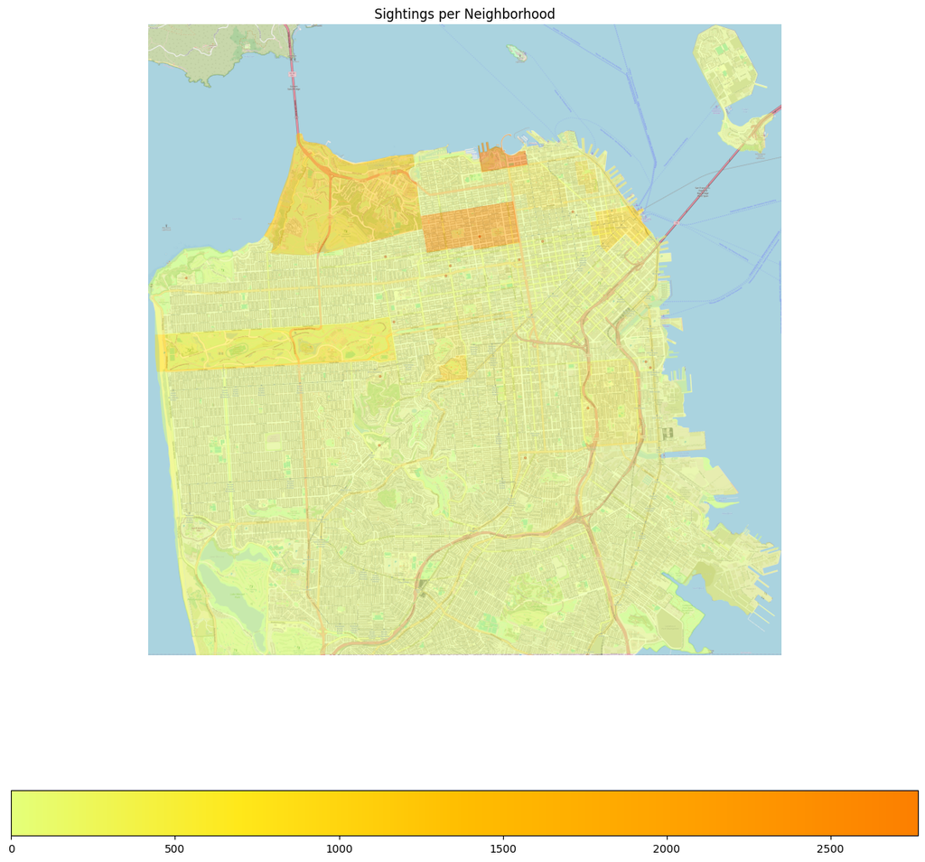

```python
data.neighborhood_distribution()
```

As you can see, there are some neighborhoods that the parrots really favor!

## Closing Words

Thank you for taking the time to read through this Notebook! Go ahead and mess around with the code cells and see what else you discover about the Wild Parrots of San Francisco!

### References

https://www.foundsf.org/index.php?title=Parrots_on_Telegraph_Hill

GBIF.org (16 April 2024) GBIF Occurrence Download https://doi.org/10.15468/dl.ch87pw